# Introduction to vtree

Exploring subsets of data using variable trees

Nick Barrowman, 12-Sep-2025, Version 5.7.0

# Introduction

vtree is a flexible tool for calculating and displaying *variable trees* — diagrams that show information about nested subsets of a data frame. vtree can be used to:

1. explore a data set interactively
2. produce customized figures for reports and publications.

Note, however, that vtree is *not* designed to build or display decision trees.

Given a data frame and simple specifications, vtree will produce a variable tree and automatically label it with counts, percentages, and other summaries.

The sections below introduce variable trees and provide an overview of the features of vtree. Or you can skip ahead and start using the `vtree` function.

## Two examples

*Subsets* play an important role in almost any data analysis. Imagine a data set of countries that includes variables named `population`, `continent`, and `landlocked`. Suppose we wish to examine subsets of the data set based on the `continent` variable. Within each of these subsets, we could examine *nested* subsets based on the `population` variable, for example, countries with populations under 30 million and over 30 million. We might continue to a third nesting based on the `landlocked` variable.

Nested subsets are at the heart of questions like the following: *Among African countries with a population over 30 million, what percentage are landlocked?* The variable tree below provides the answer:

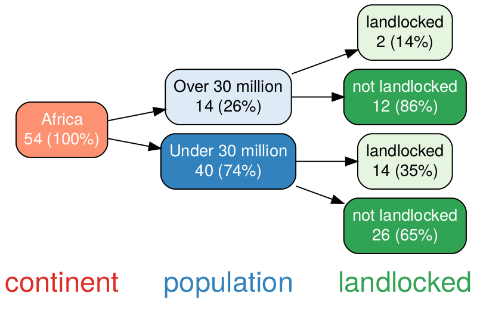

By default, vtree uses the colorful display above (to help distinguish variables and values), but if you prefer a more sedate version, you can specify a single fill color (or simply white):

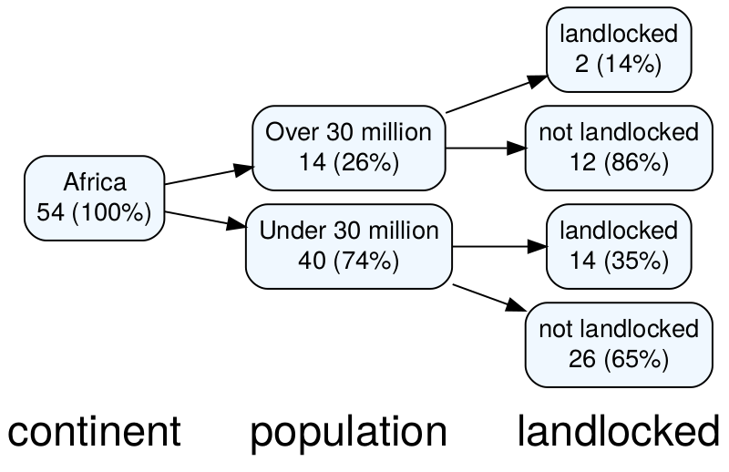

Even in simple situations like this, it can be a chore to keep track of nested subsets and calculate the corresponding percentages. The denominator used to calculate percentages may also depend on whether the variables have any missing values, as discussed later. Finally, as the number of variables increases, the magnitude of the task balloons, because the number of nested subsets grows exponentially. vtree provides a general solution to the problem of calculating nested subsets and displaying information about them.

Nested subsets arise in all kinds of situations. Consider, for example, flow diagrams for clinical studies, such as the following [CONSORT](https://www.consort-spirit.org/)-style diagram, produced by vtree.

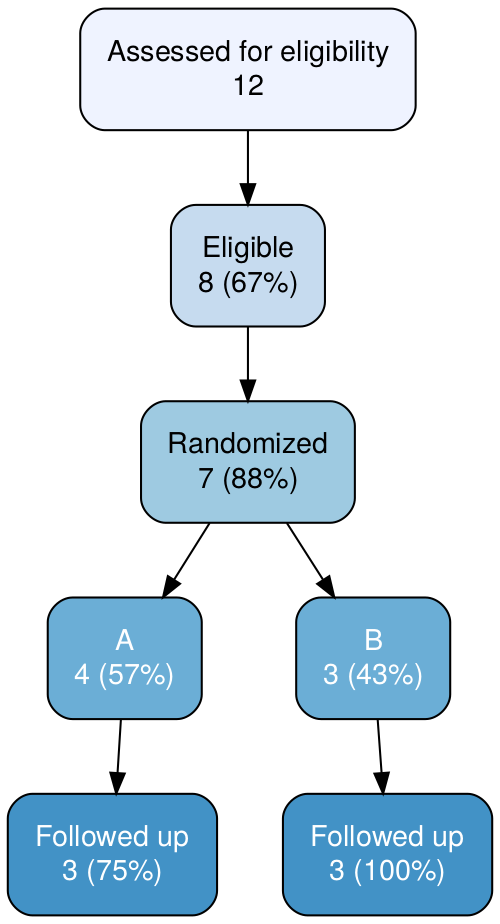

Both the structure of this variable tree and the numbers shown were automatically determined. When manual calculation and transcription are instead used to populate diagrams like this, mistakes are likely. And although the errors that make it into published articles are often minor, they can sometimes be disastrous. One motivation for developing vtree was to make flow diagrams [reproducible](https://pmc.ncbi.nlm.nih.gov/articles/PMC3383002/). The ability to reproducibly generate variable trees also means that when a data set is updated, a revised tree can be automatically produced.

At the end of this vignette, there is a collection of examples of variable trees using R datasets that you can try.

## Basic features of a variable tree

The examples that follow use a data set called `FakeData` which represents 46 fictitious patients. We’ll start by using just two variables, although variable trees are especially useful with three or more variables. The variable tree below depicts subsets defined by `Sex` (M or F) nested within subsets defined by disease `Severity` (Mild, Moderate, Severe, or NA).

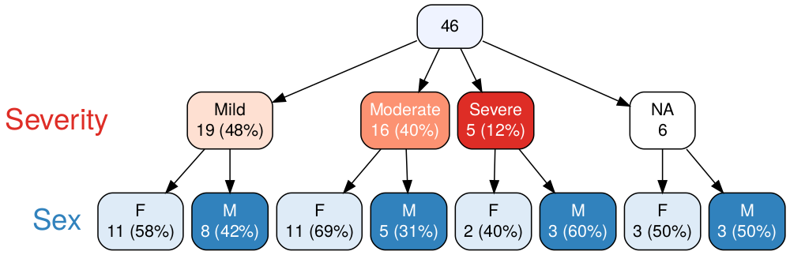

A variable tree consists of *nodes* connected by arrows. At the top of the diagram above, the *root* node of the tree contains all 46 patients. The rest of the nodes are arranged in successive layers, where each layer corresponds to a specific variable. Note that this highlights one difference between variable trees and some other kinds of trees: each layer of a variable tree corresponds to just one variable. (In a *decision tree*, by contrast, different branches can have different sequences of variable splits.)

Continuing with the variable tree above, the nodes immediately below the root represent values of `Severity` and are referred to as the *children* of the root node. In this case, `Severity` was missing (NA) for 6 patients, and there is a node for these patients. Inside each of the nodes, the number of patients is displayed and—except for in the missing value node—the corresponding percentage is also shown. Note that, by default, `vtree` displays “valid” percentages, i.e. the denominator used to calculate the percentage is the total number of *non-missing* values, 40.

The final layer of the tree corresponds to values of `Sex`. These nodes represent males and females *within subsets* defined by each value of `Severity`. In each of these nodes the percentage is calculated in terms of the number of patients in its parent node.

Like any node, a missing-value node can have children. For example, of the 6 patients for whom `Severity` is missing, 3 are female and 3 are male. By default, `vtree` displays the full missing-value structure of the specified variables.

Also by default, `vtree` automatically assigns a color palette to the nodes of each variable. `Severity` has been assigned red hues (lightest for Mild, darkest for Severe), while `Sex` has been assigned blue hues (light blue for females, dark blue for males). The node representing missing values of `Severity` is colored white to draw attention to it.

## Variable trees compared to contingency tables

A tree with two variables is similar to a two-way contingency table. In the example above, `Sex` is shown within levels of `Severity`. This corresponds to the following contingency table, where the percentages within each column add to 100%. These are called *column percentages*.

|  | Mild | Moderate | Severe | NA |
| --- | --- | --- | --- | --- |
| **F** | 11 (58%) | 11 (69%) | 2 (40%) | 3 (50%) |
| **M** | 8 (42%) | 5 (31%) | 3 (60%) | 3 (50%) |

Likewise, a tree with `Severity` shown within levels of `Sex` corresponds to a contingency table with *row percentages*.

While the contingency table above is more compact than the corresponding variable tree, some people find the variable tree more intuitive. When three or more variables are of interest, multi-way contingency tables are often used. These are typically displayed using several two-way tables, but as the number of variables increases, these become increasingly difficult to interpret. Variable trees, on the other hand, have the same simple structure regardless of the number of variables.

Note that contingency tables are not *always* more compact than variable trees. When most cells of a large contingency table are empty (in which case the table is said to be *sparse*), the corresponding variable tree may be more compact since empty nodes are not shown.

## Features of vtree

vtree is designed to be quick and easy to use, so that it is convenient for data exploration, but also flexible enough that it can be used to prepare publication-ready figures. To generate a basic variable tree, it is only necessary to specify a data frame and some variable names. However extra features extend this basic functionality to provide:

- control over labeling, colors, legends, line wrapping, and text formatting;
- flexible pruning to remove parts of the tree that are of lesser interest, which is particularly useful when a tree gets large;
- display of information about other variables in each node, including a variety of summary statistics;
- special displays for indicator variables, patterns of values, and missingness;
- support for checkbox variables from [REDCap](https://www.project-redcap.org/) databases;
- features for dichotomizing variables and checking for outliers;
- automatic generation of PNG image files and embedding in R Markdown documents; and
- interactive panning and zooming using the `svtree` function to launch a Shiny app.

In many cases, you may wish to generate several different variable trees to investigate a collection of variables in a data frame. For example, it is often useful to change the order of variables, prune parts of the tree, etc.

## Technical overview

vtree is built on open-source software: in particular Richard Iannone’s [DiagrammeR](https://rich-iannone.github.io/DiagrammeR/) package, which provides an interface to the [Graphviz](https://www.graphviz.org/) software using the [htmlwidgets](https://www.htmlwidgets.org/) framework. Additionally, vtree makes use of the [Shiny](https://posit.co/products/) package, and the svg-pan-zoom JavaScript library.

A formal description of variable trees follows.

The root node of the variable tree represents the entire data frame. The root node has a child for each observed value of the first variable that was specified. Each of these child nodes represents a subset of the data frame with a specific value of the variable, and is labeled with the number of observations in the subset and the corresponding percentage of the number of observations in the entire data frame. The *n*<sup>th</sup> layer below the root of the variable tree corresponds to the *n*<sup>th</sup> variable specified. Apart from the root node, each node in the variable tree represents the subset of its parent defined by a specific observed value of the variable at that layer of the tree, and is labeled with the number of observations in that subset and the corresponding percentage of the number of observations in its parent node.

Note that a node always represents at least one observation. And unlike a contingency table, which can have empty cells, a variable tree has no empty nodes.

# The `vtree` function

Consider a data frame named `df`, which includes discrete variables `v1` and `v2`. Suppose we wish to produce a variable tree showing subsets based on values of `v1` as well as subsets of those subsets based on values of `v2`. The variable tree can be displayed using the following command:

```r
vtree(df,"v1 v2")
```

Alternatively, you may wish to assign the output of `vtree` to an object:

```r
simple_tree <- vtree(df,"v1 v2")
```

Then it can be displayed later using:

```r
simple_tree
```

Suppose `vtree` is called without a list of variables:

```r
vtree(df)
```

In this case, only the root node is shown, representing the entire data frame. Although a tree with just one node might not seem very useful, we’ll see later that summary information about the whole data frame can be displayed there.

The `vtree` function has numerous optional parameters. For example, by default `vtree` produces a horizontal tree (that is, a tree that grows from left to right). To generate a vertical tree, specify `horiz=FALSE`.

## Mini tutorial

*This section introduces some basic features of the `vtree` function.*

To display a variable tree for a single variable, say `Severity`, use the following command:

```r
vtree(FakeData,"Severity")
```

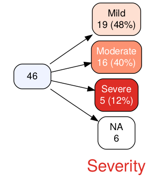

By default, next to each layer of the tree, a variable name is shown. In the example above, “Severity” is shown below the corresponding nodes. (For a vertical tree, “Severity” would be shown to the left of the nodes.) If you specify `showvarnames=FALSE`, no variable names will be shown.

`vtree` can also be used with dplyr. For example, to rename the `Severity` variable as `HowBad`, we can pipe the data frame into the `rename` function in dplyr, and then pipe the result into `vtree`:

```r
library(dplyr)
FakeData %>% rename("HowBad"=Severity) %>% vtree("HowBad")
```

Note that `vtree` also has a built-in way of renaming variables, which is an alternative to using dplyr.

Large variable trees can be difficult to display in a readable way. One approach that helps is to display the count and percentage on the same line in each node. For example, in the tree above, the label for the Moderate node is on two lines, like this:

**Moderate**  
**16 (40%)**

Specifying `sameline=TRUE` results in single-line labels, like this:

**Moderate, 16 (40%)**

### Percentages

By default, vtree shows “valid percentages”, i.e. percentages calculated using the total number of *non-missing* values as denominator. In the case of `Severity`, there are 6 missing values, so the denominator is 46 - 6, or 40. There are 19 Mild cases, and 19/40 = 0.475 so the percentage shown is 48%. No percentage is shown in the NA node since missing values are not included in the denominator.

If you prefer the denominator to represent the complete set of observations (*including* any missing values), specify `vp=FALSE`. A percentage will be shown in each of the nodes, including any NA nodes.

If you don’t wish to see percentages, specify `showpct=FALSE`, and if you don’t wish to see counts, specify `showcount=FALSE`.

### Displaying a legend and hiding node labels

To display a legend, specify `showlegend=TRUE`. Next to each variable name are “legend nodes” representing the values of that variable and colored accordingly. For each variable, the legend nodes are grouped within a light gray box. Each legend node also contains a count (with a percentage) for the value represented by that node in the whole data frame. This is known as the *marginal* count (and percentage).

When the legend is shown, labels in the nodes of the variable tree are redundant, since the colors of the nodes identify the values of the variables (although the labels may aid readability). If you prefer, you can hide the node labels, by specifying `shownodelabels=FALSE`:

```r
vtree(FakeData,"Severity Sex",showlegend=TRUE,shownodelabels=FALSE)
```

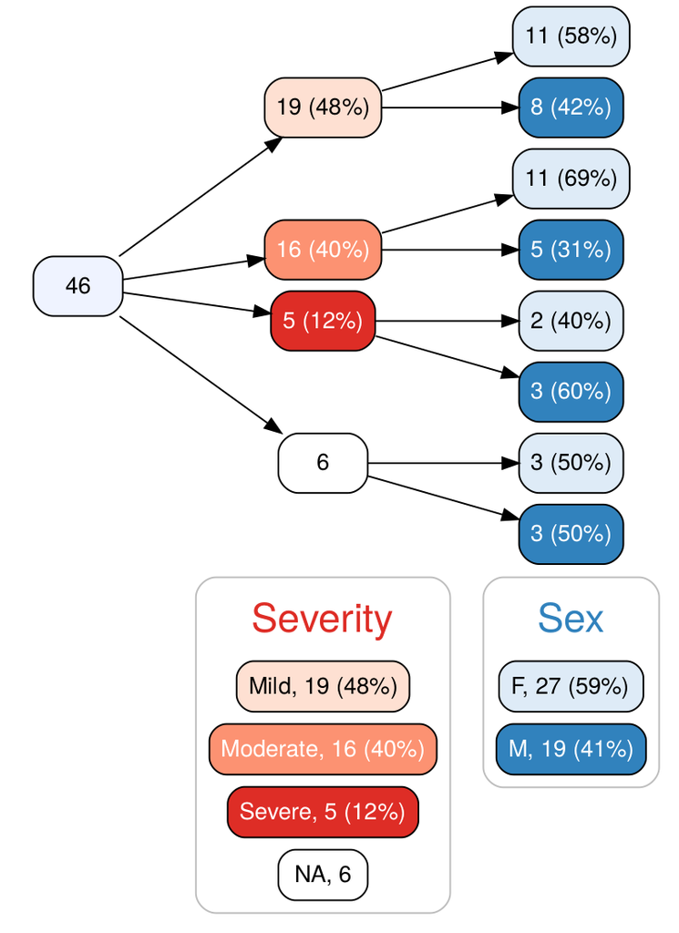

Since `Severity` is the first variable in the tree, it is not nested within another variable. Therefore the marginal counts and percentages for `Severity` shown in the legend nodes are identical to those displayed in the nodes of the variable tree. In contrast, for `Sex`, the marginal counts and percentages are different from what is shown in the nodes of the variable tree for `Sex` since they are nested within levels of `Severity`.

### Text wrapping

By default, `vtree` wraps text onto the next line whenever a space occurs after at least 20 characters. This can be adjusted, for example, to 15 characters, by specifying `splitwidth=15`. To disable line splitting, specify `splitwidth=Inf` (`Inf` means infinity, i.e. “do not split”.)

The `vsplitwidth` parameter is similarly used to control text wrapping in variable names. This is helpful with long variable names, which may be truncated unless wrapping is used. In this case text wrapping occurs not only at spaces, but also at any of the following characters:

```
. - + _ = / (
```

For example if `vsplitwidth=5`, a variable name like `First_Emergency_Visit` would be split into

`First_`  
`Emergency_`  
`Visit`

*This concludes the mini-tutorial. vtree has many more features, described in the following sections.*

## Pruning

*This section shows how to remove branches from a variable tree.*

When a variable tree gets too big, or you are only interested in certain parts of the tree, it may be useful to remove some nodes along with their descendants. This is known as *pruning*. For convenience, there are several different ways to prune a tree, described below.

### The `prune` parameter

Here’s a variable tree we’ve already seen in various forms:

```r
vtree(FakeData,"Severity Sex")
```

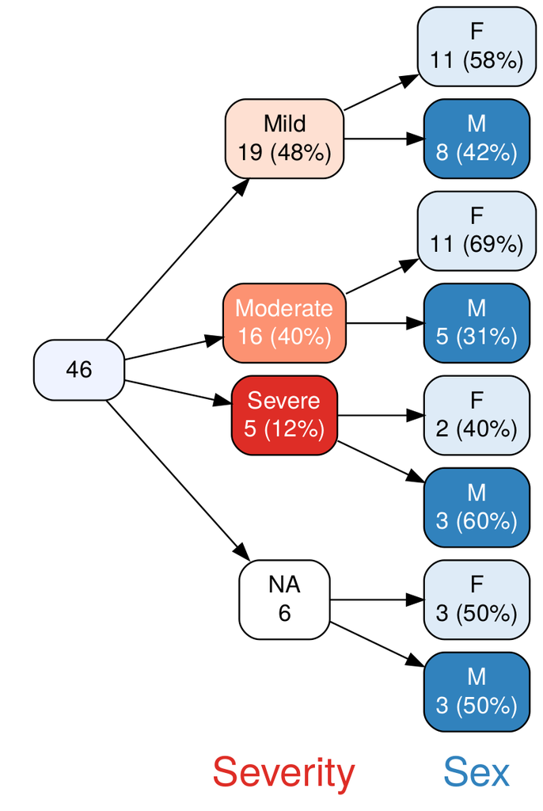

Suppose you don’t want the tree to show branches for individuals whose disease is Mild or Moderate. Specifying `prune=list(Severity=c("Mild","Moderate"))` removes those nodes, and all of their descendants:

```r
vtree(FakeData,"Severity Sex",prune=list(Severity=c("Mild","Moderate")))
```

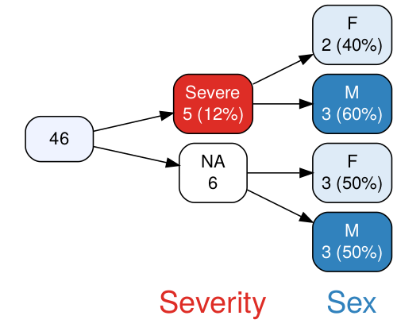

In general, the argument of the `prune` parameter is a *list* with an element named for each variable you wish to prune. In the example above, the list has a single element, named `Severity`. In turn, that element is a vector `c("Mild","Moderate")` indicating the values of `Severity` to prune.

**Caution**: Once a variable tree has been pruned, it is no longer complete. This can sometimes be confusing since not all observations are represented at certain layers of the tree. For example in the tree above, only 11 observations are shown in the `Severity` nodes and their children.

### The `keep` parameter

Sometimes it is more convenient to specify which nodes should be *retained* rather than which ones should be discarded. The `keep` parameter is used for this purpose, and can thus be considered the complement of the `prune` parameter. For example, to retain the Moderate `Severity` node:

```r
vtree(FakeData,"Severity Sex",keep=list(Severity="Moderate"))
```

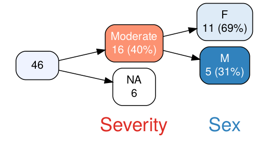

**Note**: In addition to the Moderate node, the missing value node has also been retained. In general, whenever valid percentages are used (which is the default), missing value nodes are retained when `keep` is used. This is because valid percentages are difficult to interpret without knowing the denominator, which requires knowing the number of missing values.

On the other hand, here’s what happens when `vp=FALSE`:

```r
vtree(FakeData,"Severity Sex",keep=list(Severity="Moderate"),vp=FALSE)
```

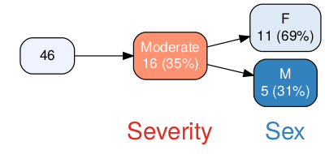

### The `prunebelow` parameter

As seen above, a disadvantage of pruning is that in the resulting tree, the counts shown in child nodes may not add up to the counts shown in their parent node.

An alternative is to prune *below* the specified nodes (i.e. to prune their descendants), so that the counts always add up. In the present example, this means that the Mild and Moderate nodes will be shown, but not their descendants. The `prunebelow` parameter is used to do this:

```r
vtree(FakeData,"Severity Sex",prunebelow=list(Severity=c("Mild","Moderate")))
```

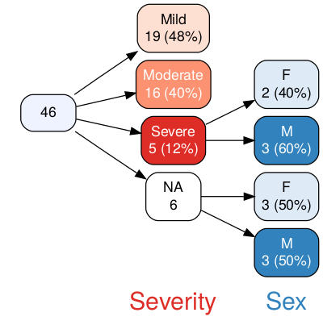

### The `follow` parameter

The complement of `prunebelow` is `follow`. Instead of specifying which nodes should be pruned below, this allows you to specify which nodes should be “followed” (that is, *not* pruned below).

### Targeted pruning

This section describes a more flexible way to prune variable trees. To explain this, first note that the `prune`, `keep`, `prunebelow`, and `follow` parameters specify pruning across all branches of the tree. For example, if you were pruning `Severity` nested within levels of `Sex`, the pruning would take place in both the M and F branches.

Sometimes, however, it is preferable to perform pruning only in specified branches of the tree. This is called *targeted* pruning, and the parameters `tprune`, `tkeep`, `tprunebelow`, and `tfollow` provide this functionality. However, their arguments have a more complex form than those of the corresponding `prune`, `keep`, `prunebelow`, and `follow` parameters because they specify the *full path* from the root of the tree all the way to the nodes to be pruned. For example to remove every `Severity` node except Moderate, but only for males, the following command can be used:

```r
vtree(FakeData,"Sex Severity",tkeep=list(list(Sex="M",Severity="Moderate")))
```

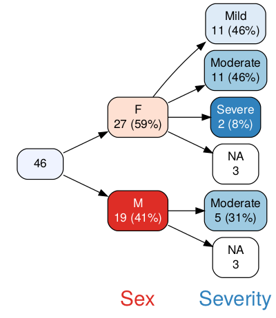

Note that the argument of `tkeep` is a list of lists, one for each path through the tree. To keep both Moderate and Severe, specify `tkeep=list(list(Sex="M",Severity=c("Moderate","Severe")))`. Now suppose that, in addition to this, within females,you want to keep just Mild. Use the following specification to do this:

```r
tkeep=list(list(Sex="M",Severity=c("Moderate","Severe")),list(Sex=F",Severity="Mild"))
```

### The `prunesmaller` parameter

As a variable tree grows, it can become difficult to see the forest for the tree. For example, the following tree is hard to read, even when `sameline=TRUE` has been specified:

```r
vtree(FakeData,"Severity Sex Age Category",sameline=TRUE)
```

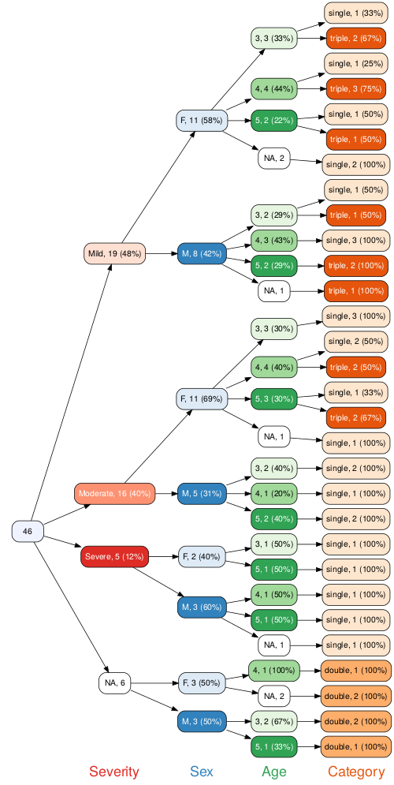

One solution is to prune nodes that contain small numbers of observations. For example if you want to only see nodes with at least 3 observations, you can specify `prunesmaller=3`, as in this example:

```r
vtree(FakeData,"Severity Sex Age Category",sameline=TRUE,prunesmaller=3)
```

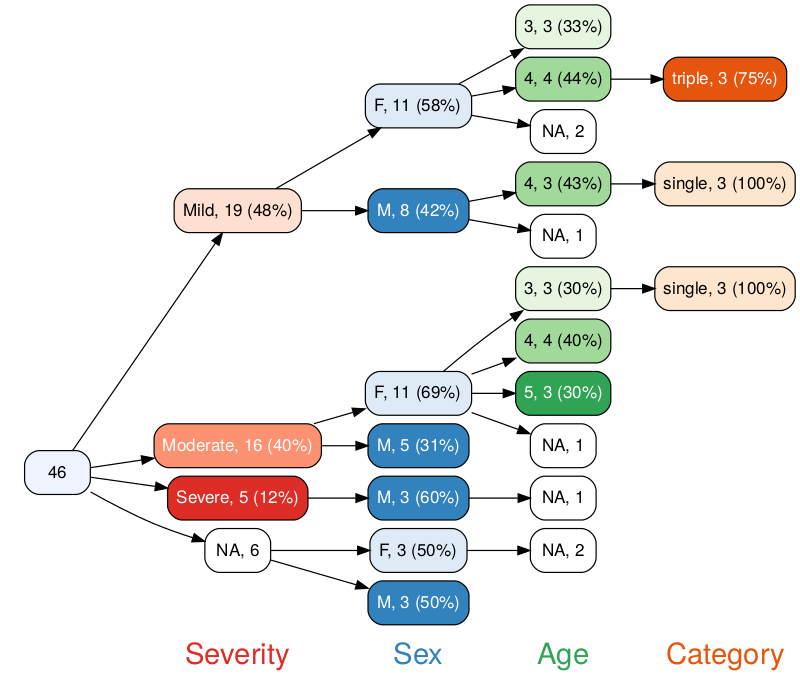

As with the `keep` parameter, when valid percentages are used (`vp=TRUE`, which is the default), nodes represent missing values will not be pruned. (As noted previously, this is because percentages are confusing when missing values are not shown.) On the other hand, when `vp=FALSE`, missing nodes will be pruned (if they are small enough).

## Labels for variables and nodes

*This section shows how to relabel variables and nodes.*

By default, `vtree` labels variables and nodes exactly as they appear in the data frame. But it is often useful to change these labels.

### Changing variable labels with the `labelvar` parameter

Suppose `Severity` in fact represents initial severity. To label it that way in the variable tree, specify `labelvar=c(Severity="Initial severity")`:

```r
vtree(FakeData,"Severity Sex",horiz=FALSE,labelvar=c(Severity="Initial severity"))
```

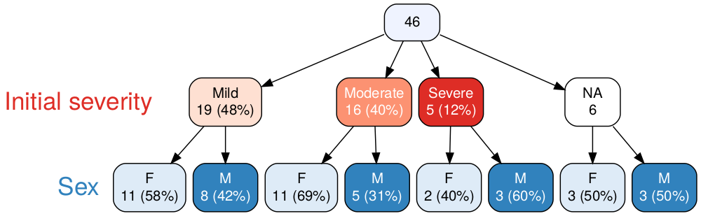

### Changing node labels with the `labelnode` parameter

By default, `vtree` labels nodes (except for the root node) using the values of the variable in question. Sometimes it is convenient to instead specify custom labels for nodes. The `labelnode` argument can be used to relabel the values. For example, you might want to use “Male” and “Female” instead of “M” and “F”.

```r
vtree(FakeData,"Group Sex",horiz=FALSE,labelnode=list(Sex=c(Male="M",Female="F")))
```

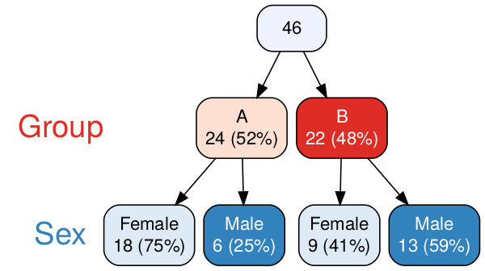

The argument of the `labelnode` parameter is specified as a list whose element names are variable names. To substitute a new label for an old label, the syntax is: `"New label"="Old label"`. Thus the full specification, as used above, is: `labelnode=list(Sex=c(Male="M",Female="F"))`.

### Targeted node labels using the `tlabelnode` parameter

Suppose in the example above that `Group` A represents children and `Group` B represents adults. In `Group` A, we would like to use the labels “girl” and “boy”, while in `Group` B we would like to use “woman” and “man”. The `labelnode` parameter cannot handle this situation because the values of `Sex` need to be labeled differently in different branches of the tree. The `tlabelnode` parameter allows “targeted” node labels.

```r
vtree(FakeData,"Group Sex",horiz=FALSE,
  labelnode=list(Group=c(Child="A",Adult="B")),
  tlabelnode=list(
    c(Group="A",Sex="F",label="girl"),
    c(Group="A",Sex="M",label="boy"),
    c(Group="B",Sex="F",label="woman"),
    c(Group="B",Sex="M",label="man")))
```

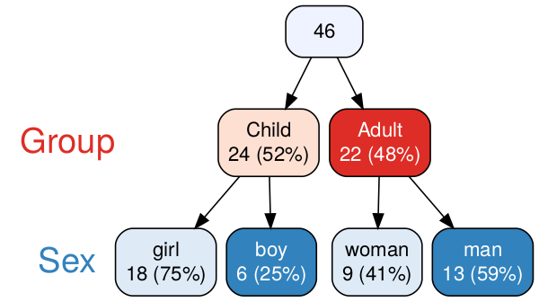

## Text and text formatting

*This section shows how to add bold, italics, and other text formatting.*

Graphviz, the open source graph visualization software that vtree is built on, supports a variety of text formatting (including bold, colors, etc.). This is used in vtree to control formatting of text such as node labels.

### Markdown-style codes for text formatting

By default, the `vtree` package uses markdown-style codes for text formatting. In the tables below, `...` represents arbitrary text.

| `\n` | insert a line break |
| --- | --- |
| `\n*l` | make the preceding line left-justified and insert a line break |
| `*...*` | display text in italics |
| `**...**` | display text in bold |
| `^...^` | display text in superscript (using 10 point font) |
| `~...~` | display text in subscript (using 10 point font) |
| `%%red ...%%` | display text in red (or whichever color is specified) |

### HTML-like codes for text formatting

As an alternative, if you specify `HTMLtext=TRUE` you can use “HTML-like labels” (implemented in Graphviz), including:

| `<BR/>` | insert a line break |
| --- | --- |
| `<BR ALIGN='LEFT'/>` | make the preceding line left-justified and insert a line break |
| `<I> ... </I>` | display text in italics |
| `<B> ... </B>` | display text in bold |
| `<SUP> ... </SUP>` | display text in superscript (using 10 point font) |
| `<SUB> ... </SUB>` | display text in subscript (using 10 point font) |
| `<FONT POINT-SIZE='10'> ... </FONT>` | set font to 10 point |
| `<FONT FACE='Times-Roman'> ... </FONT>` | set font to Times-Roman |
| `<FONT COLOR='red'> ... </FONT>` | set font to red |

See https://www.graphviz.org/doc/info/shapes.html#html for more details.

### Adding text to nodes using the `text` parameter

Suppose you wish to add the italicized text “*Excluding new diagnoses*” to any Mild nodes in the tree. The parameter `text` is used to add text to nodes. It is specified as a list with an element named for each variable. In the example below the list has one element, named `Severity`. That element in turn is a vector `c(Mild="\n*Excluding\nnew diagnoses*")` indicating that the Mild node should include additional text using Markdown-style formatting (i.e. `\n` indicates a linebreak and the asterisks around the text indicate that it should be displayed in italics):

```r
vtree(FakeData,"Group Severity",horiz=FALSE,showvarnames=FALSE,
  text=list(Severity=c(Mild="\n*Excluding\nnew diagnoses*")))
```

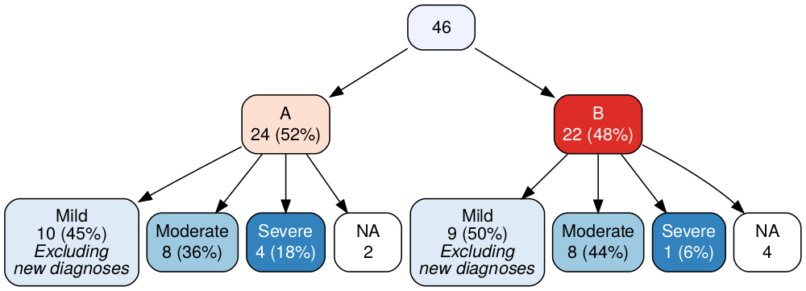

### Targeted text using the `ttext` parameter

In the example above, suppose that new diagnoses are only excluded from Mild cases in `Group` B. But the `text` parameter adds text to *all* Mild nodes. Thus, in situations like this, the `text` parameter is not sufficient. Instead, you can use the `ttext` parameter to target exactly which nodes should have the specified text.

The `ttext` parameter requires that you specify the full path from the root of the tree to the node in question, along with the text in question. The `ttext` parameter is specified as a list so that multiple targeted text strings can be specified at once. For example:

```r
vtree(FakeData,"Group Severity",horiz=FALSE,showvarnames=FALSE,
  ttext=list(
    c(Group="B",Severity="Mild",text="\n*Excluding\nnew diagnoses*"),
    c(Group="A",text="\nSweden"),
    c(Group="B",text="\nNorway")))
```

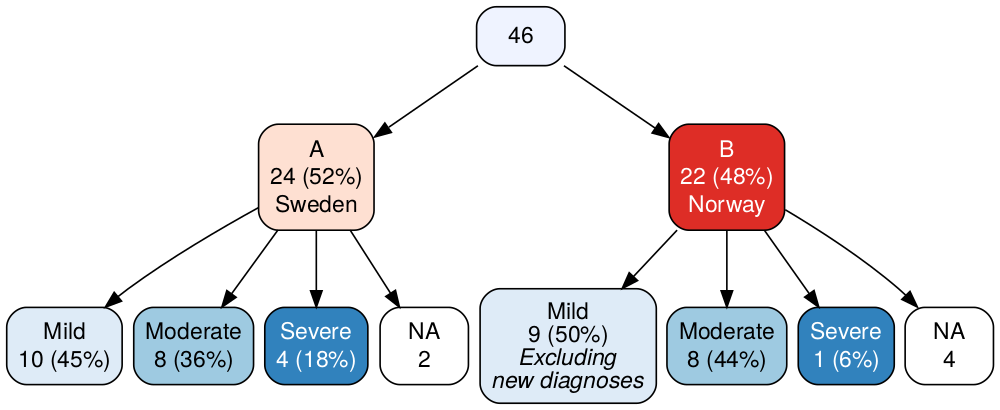

## Specification of variables

*This section shows how to control how variables appear in a variable tree.*

Sometimes it is desirable to modify a variable for use in a variable tree. For example, suppose you wish to determine how many values of `Score` are missing. This is easy to do with dplyr:

```r
library(dplyr)
FakeData %>% mutate(missingScore=is.na(Score)) %>% vtree("missingScore")
```

But vtree also offers built-in tools for variable specification. Although limited, they can be very convenient.

### prefix `is.na:`

If an individual variable name is preceded by `is.na:`, that variable will be replaced by a missing value indicator in the variable tree. (This differs from the `check.is.na` parameter, which is used to replace *all* of the specified variables with missing value indicators.) For example:

```r
vtree(FakeData,"is.na:Score")
```

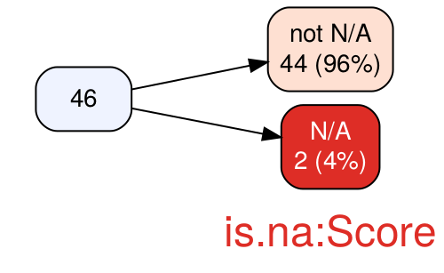

### wildcard `#`

Specifying `Ind#` matches all variable names that start with `Ind` and end with one or more numeric digits, namely `Ind1`, `Ind2`, `Ind3`, and `Ind4`. This wildcard can also be used within a variable name. For example, `visit#duration` would match `visit1duration`, `visit2duration`, etc.

### wildcard `*`

Specifying `Ind*` matches all variable names that start with `Ind` and end with any other characters (or no other characters). In `FakeData` this matches `Ind1`, `Ind2`, `Ind3`, and `Ind4` (just like `Ind#` does). But if `FakeData` contained variables named `Ind` and `Index`, they would also be matched by `Ind*`. As with the `#` wildcard, the `*` wildcard can be used within a variable name.

### prefix `i:`

“Intersections” between multiple variables can be generated using the prefix `i:`. For example, `i:Ind*` generates a variable representing the observed combinations of values of `Ind1`, `Ind2`, `Ind3`, and `Ind4`. (If at least one of the variables is missing, the combination will be missing.)

### prefix `r:` (for REDCap)

Vtree includes special support for [REDCap](https://www.project-redcap.org/) data sets. The prefix `r:` is used to indicate REDCap checkbox variables, and can be combined with other prefixes. This is described in the section on REDCap checkboxes later in this vignette.

### prefix `any:`

Sometimes a group of variables contain responses to a list of checkbox options (often with instructions to “check all that apply”). For example, suppose you have a data frame of shops, including whether they are open on Saturday (`openSaturday`) or Sunday (`openSunday`). Suppose no other variables start with `open`. Then `open*` will match both `openSaturday` and `openSunday`.

In general for a group of checkbox variables, it is often useful to know if *any* of the options were selected (i.e. checked). In the case above, we might want to know which shops are open at all on the weekend (either Saturday or Sunday).

A specification like `any:open*` is used to generate a variable that is

- `TRUE` if *any* of the matching variables has a “checked” value
- `FALSE` if none of the matching variables have “checked” values.

The parameters `checked` and `unchecked` specify which values are considered checked or unchecked respectively, and have the following defaults:

| parameter | default value |
| --- | --- |
| `checked` | `c("1","TRUE","Yes","yes")` |
| `unchecked` | `c("0","FALSE","No","no")` |

Values not listed in `checked` or `unchecked` are treated as missing values.

An alternative prefix, `anyx:`, is used to specify that missing values will be removed when performing the calculation. This matches the behavior of the R function `any` when `na.rm=TRUE` is specified.

### prefix `none:`

The logical complement (negation) of the `any:` prefix. An alternative prefix, `nonex:`, is used to specify that missing values will be removed when performing the calculation.

### prefix `all:`

A specification like `all:open*` generates a variable which is TRUE if *all* of the matching variables have a “checked” value.

An alternative prefix, `allx:`, is used to specify that missing values will be removed when performing the calculation. This matches the behavior of the R function `all` when `na.rm=TRUE` is specified.

### prefix `notall:`

The logical complement (negation) of the `all:` prefix. An alternative prefix, `notallx:`, is used to specify that missing values will be removed when performing the calculation.

### prefix `tri:`

The `tri:` prefix is useful for identifying values of a numeric variable that are *extreme* compared to the other values in a node. **Note:** Unlike other variable specifications, which take effect at the level of the entire data frame, the `tri:` prefix takes effect within each node.

The effect of this variable specification is to *trichotomize* the values of a numeric variable, i.e. to divide them into three groups:

- “mid”: values within plus or minus 1.5×IQR of the median,
- “high”: values more than 1.5×IQR above the median,
- “low”: values more than 1.5×IQR below the median.

### specification `variable=value`

When a variable takes on a large number of different values, the resulting variable tree will very large. One solution is to prune the tree, for example by keeping just the node corresponding to one value of a particular variable. An alternative is to specify the value of the variable that is of primary interest and `vtree` will dichotomize the variable at that value. For example if `Severity=Mild` is specified, the `Severity` variable will be dichotomized between `Mild` and `Not Mild`.

### specifications `variable<value`, `variable>value`

These two specifications are used to dichotomize a *numeric* variable, splitting above and below a specified value. This can be useful for identifying subsets with extreme values.

## Displaying summary statistics in nodes

*This section shows how to display information about other variables in the nodes.*

It is often useful to display information about *other* variables (apart from those that define the tree) in the nodes of a variable tree. This is particularly useful for numeric variables, which usually would not be used to build the tree since they have too many distinct values. The `summary` parameter allows you to show information (for example, a mean) about a specified variable within a subset of the data frame.

### Default summaries

Suppose you are interested in summary information for the `Score` variable for all of the observations in the data frame (i.e. in the root node). In that case you don’t need to specify any variables for the tree itself:

```r
vtree(FakeData,summary="Score")
```

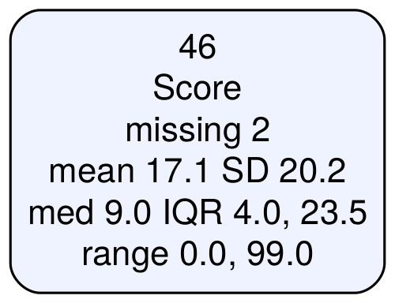

When the name of a numeric variable (in this case `"Score"`) is specified as the argument of the `summary` parameter, a default set of summary statistics (as shown above) appears: the variable name, the number of missing values, the mean and standard deviation, the median and interquartile range (IQR), and the range.

(Note, however, that if there are three or fewer observations, instead of showing the above summary statistics, the observations are simply listed.)

Suppose we’re building a variable tree based on `Severity`. We can display these summaries for `Score` in each node:

```r
vtree(FakeData,"Severity",summary="Score",horiz=FALSE)
```

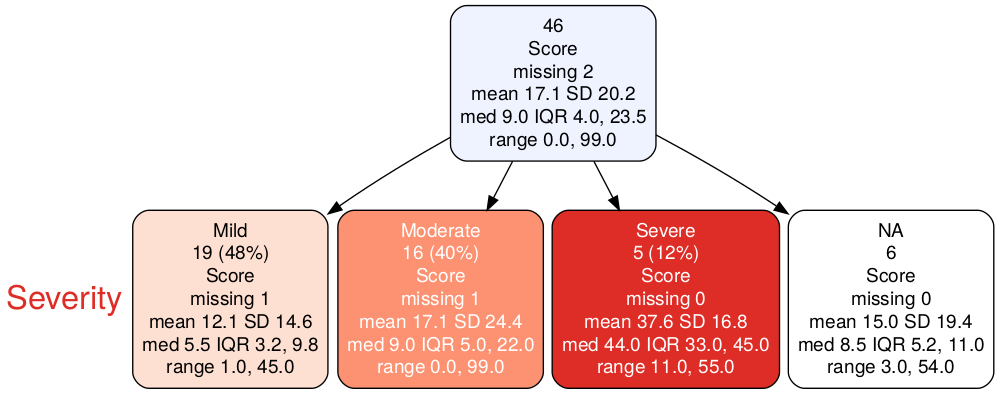

Sometimes it is helpful to extract summary information as text. For example, we might wish to access the summary information contained in the Mild node. This is explained later on, but here’s a brief example:

```r
vSeverity <- vtree(FakeData,"Severity",summary="Score",horiz=FALSE)
info <- attributes(vSeverity)$info
cat(info$Severity$Mild$.text)
```

```
##
## Score
## missing 1
## mean 12.1 SD 14.6
## med 5.5 IQR 3.2, 9.8
## range 1.0, 45.0
```

There are also default summaries for factor variables and for indicator variables. For example, `Category` is a factor variable:

```r
vtree(FakeData,summary="Category")
```

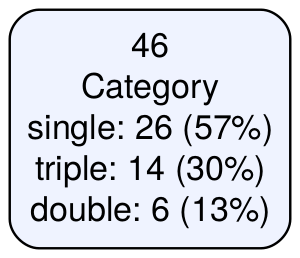

Indicator variables have two levels such as 0 / 1, or `TRUE` / `FALSE`. For example, `Event` is an indicator variable

```r
vtree(FakeData,summary="Event")
```

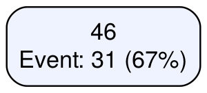

### Specification of variables in the summary argument

Variables in the `summary` argument can also be specified in a way that is similar to the specification of variables for structuring a variable tree. For example, if we wish to know the proportion of patients in each node whose `Category` is single, we specify `Category=single` in the `summary` argument:

```r
vtree(FakeData,"Severity",summary="Category=single",horiz=FALSE)
```

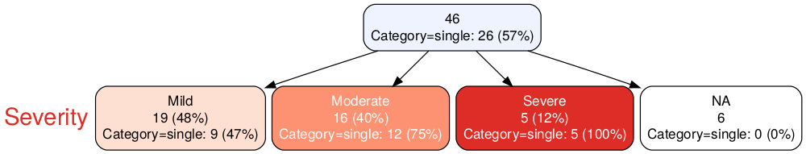

Summaries can be obtained for a collection of variables using pattern-matching, for example:

```r
vtree(FakeData,"Severity",summary="Ind*",sameline=TRUE,horiz=FALSE,just="l")
```

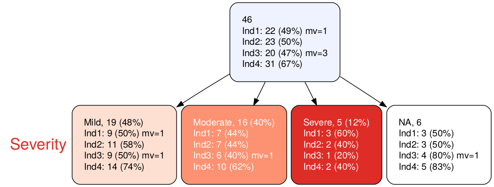

Incidentally, note that `just="l"` specifies that all text should be left-justified, which conveniently lines up all of the rows of the summary.

The `summary` argument can also use the prefixes `i:`, `any:`, `none:`, `all:`, `notall:` (as well as `anyx:`, `nonex:`, `allx:`, and `notallx:`) and wildcards `#` and `*` (similar to variable specifications). Additionally, specifications for REDCap checkboxes can be used.

### Control codes: `%noroot%`, `%leafonly%`, `%var=`*v*`%`, and `%node=`*n*`%`

By default, summary information is shown in all nodes. However, it may also be convenient to only show it in specific nodes. To control this, special codes that begin and end with `%` can be specified. The following control codes are available:

| code | summary information restricted to: |
| --- | --- |
| `%noroot%` | all nodes *except* the root |
| `%leafonly%` | leaf nodes |
| `%var=`*v*`%` | nodes of variable *v* |
| `%node=`*n*`%` | nodes named *n* |

The control codes can be specified by adding them to the end of the summary string, separated with a space. For example, to only show summary information for nodes of the `Category` variable with the value `single`:

```r
vtree(FakeData,"Severity Category",summary="Score<10 %var=Category%%node=single%",
  sameline=TRUE, showlegend=TRUE, showlegendsum=TRUE)
```

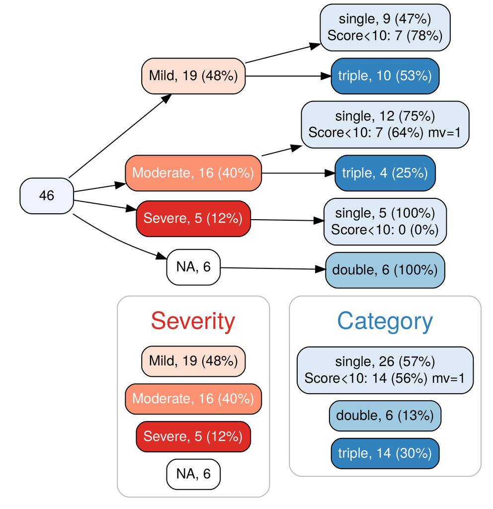

Here `showlegend=TRUE` was specified, and additionally `showlegendsum=TRUE`, which indicates that summaries should also be shown in legend nodes.

### Customized summaries

The `summary` parameter also allows for customized summaries. For example, we might wish to display only the mean `Score` in each node of the tree. The `%mean%` code is used to represent the mean of the specified variable (preceded here by a line break, `\n`).

```r
vtree(FakeData,"Severity",summary="Score \nmean score\n%mean%",sameline=TRUE,horiz=FALSE)
```

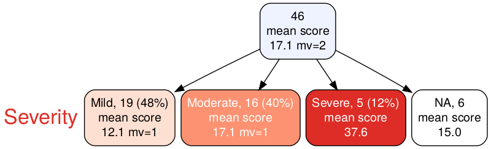

In addition to the `%mean%` code, numerous other summary codes are supported, as listed in the table below. When such a code is present, the default summary is not shown. Instead, any text that is provided—in this case `\nmean score\n`—is shown, together with the requested summary information. If there are any missing values in a node, the number of missing values is shown using the abbreviation `mv`. To see summaries without any decimals, specify `cdigits=0`.

| summary code | result |
| --- | --- |
| `%mean%` | mean (variant: `%meanx%` does not report missing values*) |
| `%SD%` | standard deviation (variant: `%SDx%` does not report missing values*) |
| `%sum%` | sum (variant: `%sumx%` does not report missing values*) |
| `%min%` | minimum (variant: `%minx%` does not report missing values*) |
| `%max%` | maximum (variant: `%maxx%` does not report missing values*) |
| `%range%` | range (variant: `%rangex%` does not report missing values*) |
| `%median%` | median, i.e. p50 (variant: `%medianx%` does not report missing values*) |
| `%IQR%` | IQR, i.e. p25, p75 (variant: `%IQRx%` does not report missing values*) |
| `%freqpct%` | frequency and percentage of values of a variable (variant: `%freqpct_%` shows each value on a separate line) |
| `%freq%` | frequency of values of a variable (variant: `%freq_%` shows each value on a separate line) |
| `%pY%` | *Y*th percentile (e.g. `p50` means the 50th percentile) |
| `%npct%` | frequency and percentage of a logical variable. By default “valid percentages” are used. Any missing values are also reported. |
| `%pct%` | same as `%npct%` but percentage only (with no parentheses). |
| `%list%` | list of individual values, separated by commas (variant: `%list_%` shows each value on a separate line) |
| `%mv%` | the number of missing values |
| `%nonmv%` | the number of non-missing values |
| `%v%` | the name of the variable |

**Caution is recommended when suppressing missing values.*

The `summary` argument can include any number of these codes, mixed with text and formatting codes.

### The `%trunc%` code

It is sometimes convenient to see individual values of a variable in each node. A good example is ID numbers. To do this, use the `%list%` code. When a value occurs more than once in the subset, it will be followed by a count of the number of repetitions in parentheses.

When there are many individual values, it is often convenient to truncate the output. If you specify `%trunc=`*N*`%`, summary information will be truncated after *N* characters, and followed by “…”.

### R expressions in the summary argument

Rather than starting the `summary` argument with a variable name, an R expression involving variables in the data frame can be given, as long as it does not contain any spaces.

```r
vtree(FakeData,"Severity Category",
  summary="(Post-Pre)/Pre \nmean = %mean%",sameline=TRUE,horiz=FALSE,cdigits=1)
```

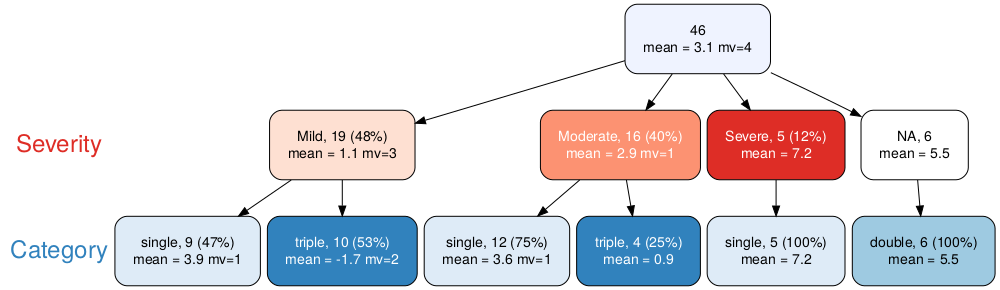

Expressions involving functions can also be used; for example `sqrt(abs(Post/Pre))`.

### More than one variable

Sometimes it is useful to display summary information for more than one variable. To do this, specify `summary` as a *vector* of character strings. For example:

```r
vtree(FakeData,"Severity",horiz=FALSE,showvarnames=FALSE,splitwidth=Inf,sameline=TRUE,
  summary=c("Score \nScore: mean (SD) %meanx% (%SD%)","Pre \nPre: range %range%"))
```

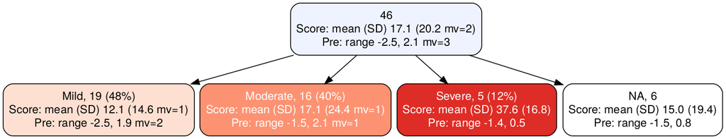

### Targeted summaries

```r
vtree(FakeData,"Age Sex",tsummary=list(list(Age="5",Sex="M","id \n%list%")),horiz=FALSE)
```

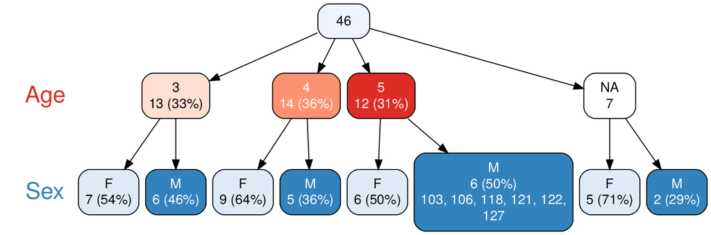